# Final Project

Gus Vu & Jeremy Bednar

[figure not shown]

### Libraries & Loading Both Data Sources

```r
library(jsonlite)
library(lubridate)
library(gghighlight)
library(spotifyr)
library(tidyverse)
library(knitr)
library(ggplot2)
library(plotly)
library(esquisse)
library(dplyr)
library(purrr)
library(ggridges)
library(reticulate)

# Gus history
streamHistoryGus0 <- fromJSON("GusStreamingHistory0.json", flatten = TRUE)
streamHistoryGus1 <- fromJSON("GusStreamingHistory1.json", flatten = TRUE)

# Jeremy history
streamHistoryJeremy0 <- fromJSON("JeremyStreamingHistory0 copy.json", flatten = TRUE)
streamHistoryJeremy1 <- fromJSON("JeremyStreamingHistory1 copy.json", flatten = TRUE)
streamHistoryJeremy2 <- fromJSON("JeremyStreamingHistory2 copy.json", flatten = TRUE)
streamHistoryJeremy3 <- fromJSON("JeremyStreamingHistory3 copy.json", flatten = TRUE)
streamHistoryJeremy4 <- fromJSON("JeremyStreamingHistory4 copy.json", flatten = TRUE)

# Joining Data Frames Per User + converting "msPlayed" to seconds
streamHistoryJeremy <-
  streamHistoryJeremy0 %>%
  full_join(streamHistoryJeremy1) %>%
  full_join(streamHistoryJeremy2) %>%
  full_join(streamHistoryJeremy3) %>%
  full_join(streamHistoryJeremy4) %>%
  mutate(Listener = "Jeremy") %>%
  mutate(sPlayed = msPlayed/1000)
streamHistoryJeremy
```

| endTime | artistName | trackName | msPlayed | Listener | sPlayed |
| --- | --- | --- | --- | --- | --- |
| 2020-11-03 16:55 | NLE Choppa | Picture Me Grapin’ | 208831 | Jeremy | 208.831 |
| 2020-11-11 03:01 | iann dior | Darkside | 92351 | Jeremy | 92.351 |
| 2020-11-12 00:17 | Drake | Chicago Freestyle (feat. Giveon) | 68835 | Jeremy | 68.835 |
| 2020-11-12 01:12 | XXXTENTACION | Fuck Love (feat. Trippie Redd) | 146519 | Jeremy | 146.519 |
| 2020-11-12 01:15 | Wifisfuneral | I Can't Fold | 189999 | Jeremy | 189.999 |
| 2020-11-12 01:18 | Unknown Artist | Unknown Track | 168294 | Jeremy | 168.294 |
| 2020-11-12 01:21 | Denzel Curry | WISH FEAT. KIDDO MARV | 192013 | Jeremy | 192.013 |
| 2020-11-12 01:25 | YNW Melly | Freaky Girl | 214304 | Jeremy | 214.304 |
| 2020-11-12 01:27 | ShooterGang Kony | Skoompin' | 158495 | Jeremy | 158.495 |
| 2020-11-12 01:30 | Beast Coast | Distance (feat. Issa Gold & Erick The Architect) | 34351 | Jeremy | 34.351 |

[output cut: 990 more lines]

```r
streamHistoryGus <-
  streamHistoryGus0 %>%
  full_join(streamHistoryGus1) %>%
  mutate(Listener = "Gus") %>%
  mutate(sPlayed = msPlayed/1000)
streamHistoryGus
```

| endTime | artistName | trackName | msPlayed | Listener | sPlayed |
| --- | --- | --- | --- | --- | --- |
| 2020-11-02 05:53 | Drake | Take Care | 49007 | Gus | 49.007 |
| 2020-11-11 21:21 | Lil Pete | All I Do (feat. Philthy Rich) | 40739 | Gus | 40.739 |
| 2020-11-12 00:30 | 21 Savage | Secret (feat. Summer Walker) | 81536 | Gus | 81.536 |
| 2020-11-12 01:52 | 21 Savage | Secret (feat. Summer Walker) | 3366 | Gus | 3.366 |
| 2020-11-12 02:00 | 2Pac | Do For Love | 509329 | Gus | 509.329 |
| 2020-11-12 02:05 | 2Pac | All About U (ft. Nate Dogg, Snoop Dogg, Fatal, Yani Hadati) | 276813 | Gus | 276.813 |
| 2020-11-12 02:05 | Gang Starr | Betrayal | 19530 | Gus | 19.530 |
| 2020-11-12 02:09 | Woodie | The Streets Are Callin' Me | 245640 | Gus | 245.640 |
| 2020-11-12 02:14 | The Notorious B.I.G. | I Got a Story to Tell - 2014 Remaster | 283053 | Gus | 283.053 |
| 2020-11-12 02:15 | GZA | Liquid Swords | 54288 | Gus | 54.288 |

[output cut: 990 more lines]

```r
#API Access (Gus)
Sys.setenv(SPOTIFY_CLIENT_ID = '949891eb08fe47cb8e6e031a841b76ba')
Sys.setenv(SPOTIFY_CLIENT_SECRET = '54b9813cd7bc40eca15514be0b52701b')

access_token <- get_spotify_access_token()
```

#### Research Question

Essentially, we want to recreate Spotify Wrapped in our own way. One question we might ask is, “How much time have I spent listening to music this year?” or, “How has my music taste changed over time?”. With our data set, we could answer these questions and many more.

#### Where/How Data was Found

```r
Link1 <- "https://www.spotify.com/us/account/privacy/"
Link2 <- "https://towardsdatascience.com/get-your-spotify-streaming-histo ry-with-python-d5a208bbcbd3"
```

We knew that Spotify collects the data necessary for a project like this because of their Spotify Wrapped every year. After some researching, we found out that it can be requested and used personally.

#### Examine the data source

The data is collected by Spotify. Cases come in the form of listening instances based on log information. Therefore, the data will show listening time intervals as well as many other variables pertaining to the songs that have been listened to. The following audio features can be obtained through the Spotify API. These features include but are not limited to…

- acousticness — how acoustic
- danceability — self-explanatory
- energy — how ’fast, loud an noisy
- instrumentalness — the less vocals, the higher
- liveness — whether there is audience in the recording
- loudness — self-explanatory
- speechiness — the more spoken words, the higher
- valence — whether the track sounds happy or sad
- tempo — the bpm

Spotify created this data for marketing but it is available to users upon request.

## Analysis

From here on out, we worked with the data in each of our “streamHistory” tables, joined the data tables, compared our listening habits, and even made use of Spotify’s API. It’s easiest to look at each chunk as if it were a mini-project for a better understanding of our process. They all do something unique but accomplish our goals set by the research question. Throughout our analysis, we found that our data and results were slightly different than what Spotify Wrapped told us, which will be explained as you go along.

#### Total Listening Length Per User (in seconds)

```r
#Total listening time of the time interval for which the data was collected (including "banned artists")
streamHistoryTotalJeremy <-
  streamHistoryJeremy %>%
  summarise(TotalPlayed = sum(sPlayed))
streamHistoryTotalJeremy
```

| TotalPlayed |
| --- |
| 6386973 |

```r
streamHistoryTotalGus <-
  streamHistoryGus %>%
  summarise(TotalPlayed = sum(sPlayed))
streamHistoryTotalGus
```

| TotalPlayed |
| --- |
| 1716738 |

```r
NA
```

The first thing we did was total our listening time for each of our tables. We noticed that the total was slightly higher than what Wrapped told us. The reason for this discrepancy is that our data was collected for a longer period of time than what was used for our Wrapped. Also, our data includes time listened to an “Unknown Track” or an “Unknown Artist”. This is the accumulated listening time for unofficial songs in our respective libraries. In other words, it’s the data Spotify collected on tracks that we downloaded and listened to from somewhere other than Spotify. For whatever reason, they don’t include this data in their analysis.

#### Listening Length Per User By Song

```r
#total listening time per song
streamHistoryJeremySong <-
    streamHistoryJeremy %>%
    group_by(trackName, artistName) %>%
    select(artistName, trackName, sPlayed) %>%
    summarize(sTotal = sum(sPlayed)) %>%
    mutate(Listener = "Jeremy") %>%
    arrange(desc(sTotal))
streamHistoryJeremySong
```

| trackName | artistName | sTotal | Listener |
| --- | --- | --- | --- |
| Unknown Track | Unknown Artist | 845191.917 | Jeremy |
| GONE, GONE / THANK YOU | Tyler, The Creator | 80347.905 | Jeremy |
| Grab the Wheel | Lil Uzi Vert | 55230.286 | Jeremy |
| 505 | Arctic Monkeys | 52493.784 | Jeremy |
| Drankin N Smokin | Future | 46099.775 | Jeremy |
| The Way Life Goes (feat. Oh Wonder) | Lil Uzi Vert | 39208.884 | Jeremy |
| Loaded | Lil Uzi Vert | 36222.623 | Jeremy |
| 20 Min | Lil Uzi Vert | 35728.939 | Jeremy |
| Yam Yam | No Vacation | 34847.478 | Jeremy |
| How to Talk | Lil Uzi Vert | 34495.281 | Jeremy |

[output cut: 990 more lines]

```r
streamHistoryGusSong <-
    streamHistoryGus %>%
    group_by(trackName, artistName) %>%
    select(artistName, trackName, sPlayed) %>%
    summarize(sTotal = sum(sPlayed)) %>%
    mutate(Listener = "Gus") %>%
    arrange(desc(sTotal))
streamHistoryGusSong
```

| trackName | artistName | sTotal | Listener |
| --- | --- | --- | --- |
| Unknown Track | Unknown Artist | 41134.691 | Gus |
| Ex-Factor | Ms. Lauryn Hill | 22208.889 | Gus |
| Doo Wop (That Thing) | Ms. Lauryn Hill | 15075.987 | Gus |
| Mr. Carter | Lil Wayne | 15036.663 | Gus |
| Differences | Ginuwine | 14951.809 | Gus |
| Body On Me | Ashanti | 12535.646 | Gus |
| You Bring Me Joy | Mary J. Blige | 11864.796 | Gus |
| To Zion (feat. Carlos Santana) | Ms. Lauryn Hill | 11618.258 | Gus |
| Best I Ever Had | Drake | 11340.966 | Gus |
| Golden | Jill Scott | 10506.719 | Gus |

[output cut: 990 more lines]

```r
NA
```

This chunk builds off the last. We grouped by the song variable so we could identify our most listened to songs for the given time period. We chose to include the unofficial track data here.

#### Listening Length Per User By Artist

```r
#total listening time for all artists
streamHistoryJeremyArtist <-
    streamHistoryJeremy %>%
    group_by(artistName) %>%
    select(artistName, trackName, sPlayed) %>%
    summarize(sTotal = sum(sPlayed)) %>%
    mutate(Listener = "Jeremy") %>%
    arrange(desc(sTotal))
streamHistoryJeremyArtist
```

| artistName | sTotal | Listener |
| --- | --- | --- |
| Lil Uzi Vert | 905847.814 | Jeremy |
| Unknown Artist | 845191.917 | Jeremy |
| Tyler, The Creator | 381901.723 | Jeremy |
| Future | 250194.800 | Jeremy |
| Juice WRLD | 172556.467 | Jeremy |
| Playboi Carti | 163456.903 | Jeremy |
| Isaiah Rashad | 142750.684 | Jeremy |
| Polo G | 120246.670 | Jeremy |
| jxdn | 105495.991 | Jeremy |
| J. Cole | 96944.144 | Jeremy |

[output cut: 845 more lines]

```r
streamHistoryGusArtist <-
    streamHistoryGus %>%
    group_by(artistName) %>%
    select(artistName, trackName, sPlayed) %>%
    summarize(sTotal = sum(sPlayed)) %>%
    mutate(Listener = "Gus") %>%
    arrange(desc(sTotal))
streamHistoryGusArtist
```

| artistName | sTotal | Listener |
| --- | --- | --- |
| Ms. Lauryn Hill | 87772.160 | Gus |
| Erykah Badu | 86814.618 | Gus |
| 2Pac | 68046.945 | Gus |
| Lil Wayne | 57205.344 | Gus |
| JAY-Z | 53467.748 | Gus |
| Kid Cudi | 44123.332 | Gus |
| Jill Scott | 42738.427 | Gus |
| Unknown Artist | 41134.691 | Gus |
| Mary J. Blige | 34216.350 | Gus |
| Kanye West | 30511.887 | Gus |

[output cut: 829 more lines]

```r
NA
```

This chunk is identical to the last, but we changed the group by variable from song to artist.

#### Gus and Jeremy Full Join (streamHistory, Song, and Artist)

```r
#combining the original streamHistory tables for Gus & Jeremy
streamHistoryGusAndJeremyOG <-
  streamHistoryGus %>%
  full_join(streamHistoryJeremy)
#total listening time per song for both users
streamHistoryGusAndJeremySong<-
  streamHistoryGusSong %>%
  full_join(streamHistoryJeremySong) %>%
  filter(trackName != "Unknown Track") %>%
  arrange(desc(sTotal))
#total listening time for all artists either user listened to
streamHistoryGusAndJeremyArtist <-
  streamHistoryGusArtist %>%
  full_join(streamHistoryJeremyArtist) %>%
  arrange(desc(sTotal))
streamHistoryGusAndJeremySong %>%
  head(10)
```

| trackName | artistName | sTotal | Listener |
| --- | --- | --- | --- |
| GONE, GONE / THANK YOU | Tyler, The Creator | 80347.90 | Jeremy |
| Grab the Wheel | Lil Uzi Vert | 55230.29 | Jeremy |
| 505 | Arctic Monkeys | 52493.78 | Jeremy |
| Drankin N Smokin | Future | 46099.78 | Jeremy |
| The Way Life Goes (feat. Oh Wonder) | Lil Uzi Vert | 39208.88 | Jeremy |
| Loaded | Lil Uzi Vert | 36222.62 | Jeremy |
| 20 Min | Lil Uzi Vert | 35728.94 | Jeremy |
| Yam Yam | No Vacation | 34847.48 | Jeremy |
| How to Talk | Lil Uzi Vert | 34495.28 | Jeremy |
| Heart In Pieces | Future | 33646.32 | Jeremy |

```r
streamHistoryGusAndJeremyArtist %>%
  head(10)
```

| artistName | sTotal | Listener |
| --- | --- | --- |
| Lil Uzi Vert | 905847.81 | Jeremy |
| Unknown Artist | 845191.92 | Jeremy |
| Tyler, The Creator | 381901.72 | Jeremy |
| Future | 250194.80 | Jeremy |
| Juice WRLD | 172556.47 | Jeremy |
| Playboi Carti | 163456.90 | Jeremy |
| Isaiah Rashad | 142750.68 | Jeremy |
| Polo G | 120246.67 | Jeremy |
| jxdn | 105495.99 | Jeremy |
| J. Cole | 96944.14 | Jeremy |

```r
NA
NA
```

In this chunk, we joined all of the tables made in the previous chunks so we could compare our data for songs and artists. It also serves as a good indication of our listening habits. For instance, we can see that Jeremy listens to significantly more music than Gus, and he binge listens to both songs and artists more than Gus.

#### Top 10 Songs

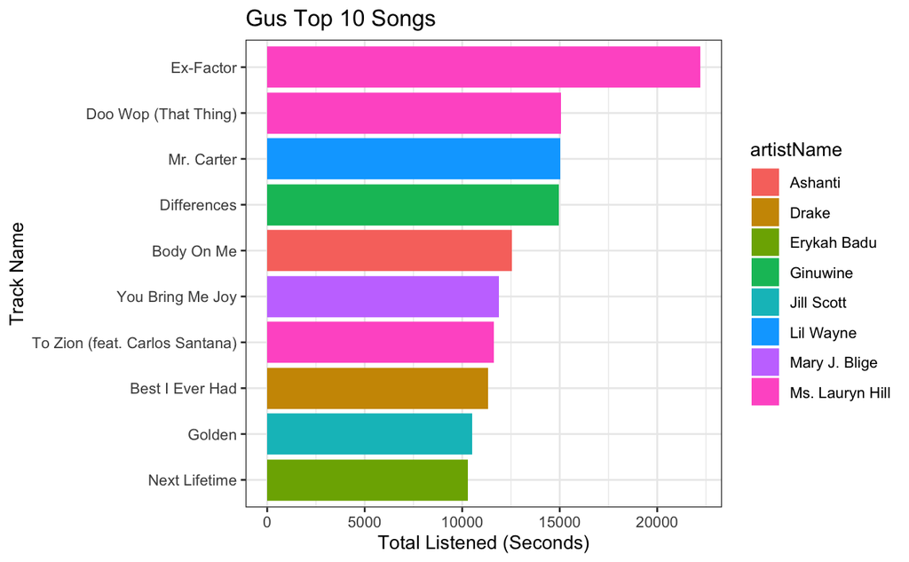

```r
#Top 10 songs Gus
GusTopTenSong <-
  streamHistoryGusSong %>%
  filter(trackName != "Unknown Track") %>%
  arrange(desc(sTotal)) %>%
  head(10)
ggplot(GusTopTenSong) +
  aes(x = reorder(trackName,+sTotal), fill = artistName, weight = sTotal) +
  geom_bar() +
  scale_fill_hue(direction = 1) +
  labs(title = "Gus Top 10 Songs") +
  coord_flip() +
  theme_bw() +
  xlab("Track Name") +
  ylab("Total Listened (Seconds)")
```

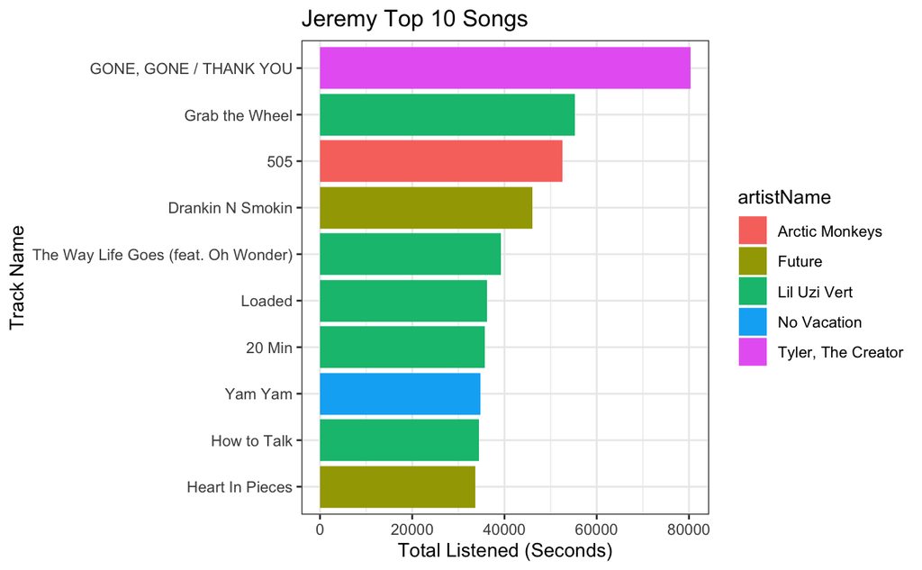

```r
#Top 10 Songs Jeremy
JeremyTopTenSong <-
  streamHistoryJeremySong %>%
  filter(trackName != "Unknown Track") %>%
  arrange(desc(sTotal)) %>%
  head(10)
ggplot(JeremyTopTenSong) +
  aes(x = reorder(trackName,+sTotal), fill = artistName, weight = sTotal) +
  geom_bar() +
  scale_fill_hue(direction = 1) +
  labs(title = "Jeremy Top 10 Songs") +
  coord_flip() +
  theme_bw() +
  xlab("Track Name") +
  ylab("Total Listened (Seconds)")
```

This graphic compares the top 10 most listened to songs for each of us in descending order. It acts as a good visual representation of our analysis, much like how Spotify does it. We decided to omit the data collected for unofficial tracks because the song objects don’t have a unique identifier to collect information on. Although there are many different unofficial tracks that we both listen to, Spotify can’t collect information on them individually, therefore causing it to be unfit for comparison.

#### Top 10 Artists

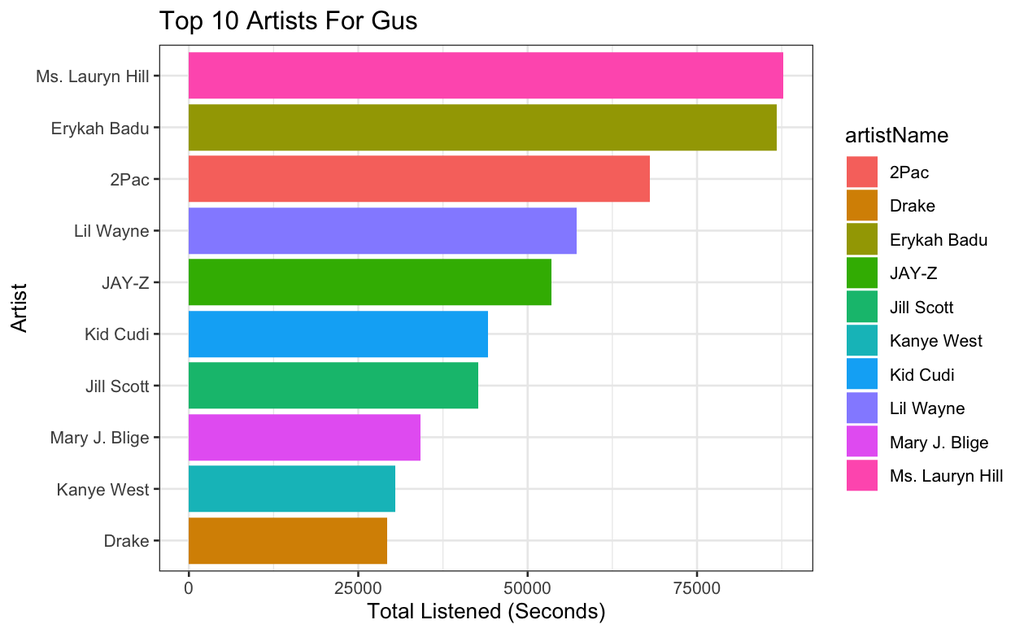

```r
#graphs and visuals for significant information
GusTopTenArtist <-
  streamHistoryGusArtist %>%
  filter(artistName != "Unknown Artist") %>%
  arrange(desc(sTotal)) %>%
  head(10)
ggplot(GusTopTenArtist) +
  aes(x = reorder(artistName,+sTotal), fill = artistName, weight = sTotal) +
  geom_bar() +
  scale_fill_hue(direction = 1) +
  labs(title = "Top 10 Artists For Gus") +
  coord_flip() +
  theme_bw() +
  xlab("Artist") +
  ylab("Total Listened (Seconds)")
```

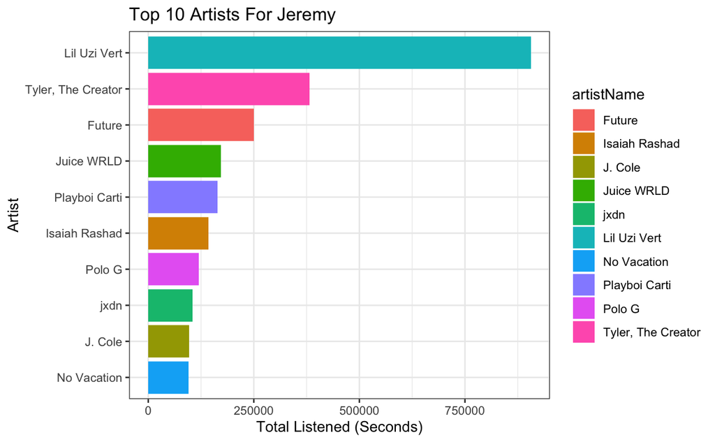

```r
JeremyTopTenArtist <-
  streamHistoryJeremyArtist %>%
  filter(artistName != "Unknown Artist") %>%
  arrange(desc(sTotal)) %>%
  head(10)
ggplot(JeremyTopTenArtist) +
  aes(x = reorder(artistName,+sTotal), fill = artistName, weight = sTotal) +
  geom_bar() +
  scale_fill_hue(direction = 1) +
  labs(title = "Top 10 Artists For Jeremy") +
  coord_flip() +
  theme_bw() +
  xlab("Artist") +
  ylab("Total Listened (Seconds)")
```

This is the same visual representation as the last, but for artists rather than songs.

#### Initial CoPlaylist

```r
#creating a playlist of songs that both users listen to
CoPlaylist <-
  streamHistoryJeremySong %>%
  filter(sTotal <= 600000) %>%
  inner_join(streamHistoryGusSong, by = c("trackName" = "trackName","artistName" = "artistName"))
CoPlaylist
```

| trackName | artistName | sTotal.x | Listener.x | sTotal.y | Listener.y |
| --- | --- | --- | --- | --- | --- |
| ...And to Those I Love, Thanks for Sticking Around | $uicideboy$ | 862.822 | Jeremy | 343.591 | Gus |
| ...And To Those I Love, Thanks For Sticking Around | $uicideboy$ | 1352.423 | Jeremy | 158.997 | Gus |
| 10 Freaky Girls (with 21 Savage) | Metro Boomin | 2727.012 | Jeremy | 163.788 | Gus |
| 2 Of Amerikaz Most Wanted | 2Pac | 1.408 | Jeremy | 3579.978 | Gus |
| 20 Min | Lil Uzi Vert | 35728.939 | Jeremy | 17.333 | Gus |
| 223's (feat. 9lokknine) | YNW Melly | 4110.150 | Jeremy | 176.640 | Gus |
| 4r Da Squaw | Isaiah Rashad | 1676.366 | Jeremy | 14.558 | Gus |
| 505 | Arctic Monkeys | 52493.784 | Jeremy | 154.027 | Gus |
| 734 | Juice WRLD | 3589.107 | Jeremy | 196.146 | Gus |
| 9 5 . s o u t h | J. Cole | 106.196 | Jeremy | 196.946 | Gus |

[output cut: 192 more lines]

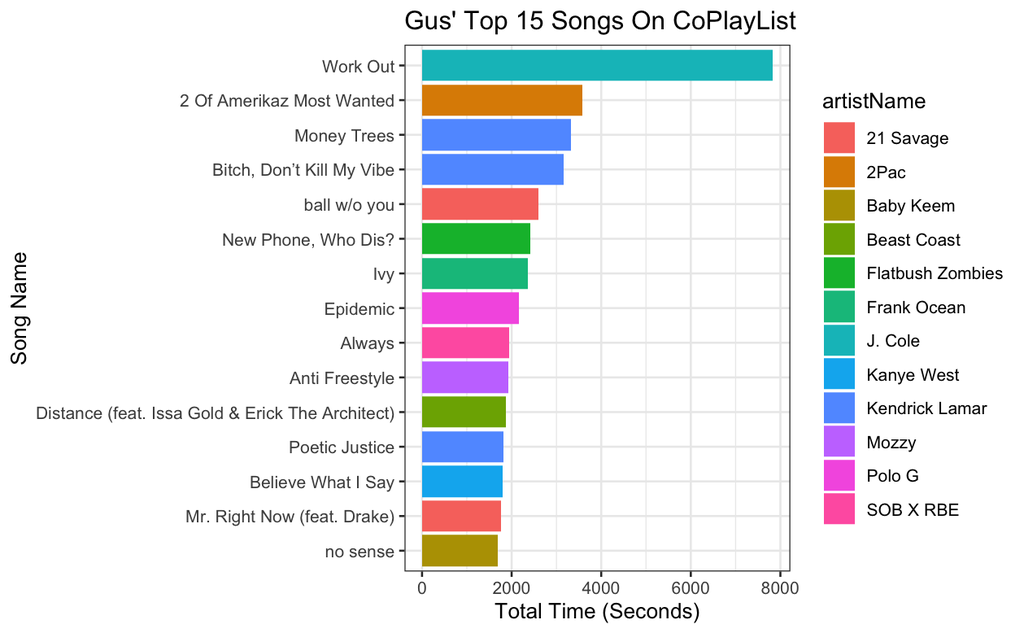

```r
#songs each of us listen to a lot that the other has heard before
GusCoPlay <-
  CoPlaylist %>%
  select(trackName,artistName,sTotal.y,Listener.y) %>%
  arrange(desc(sTotal.y)) %>%
  head(15)
ggplot(GusCoPlay) +
  aes(x = reorder(trackName,+sTotal.y), fill = artistName, weight = sTotal.y) +
  geom_bar() +
  scale_fill_hue(direction = 1) +
  labs(title = "Gus' Top 15 Songs On CoPlayList") +
  ylab("Total Time (Seconds)") +
  xlab("Song Name") +
  coord_flip() +
  theme_bw()
```

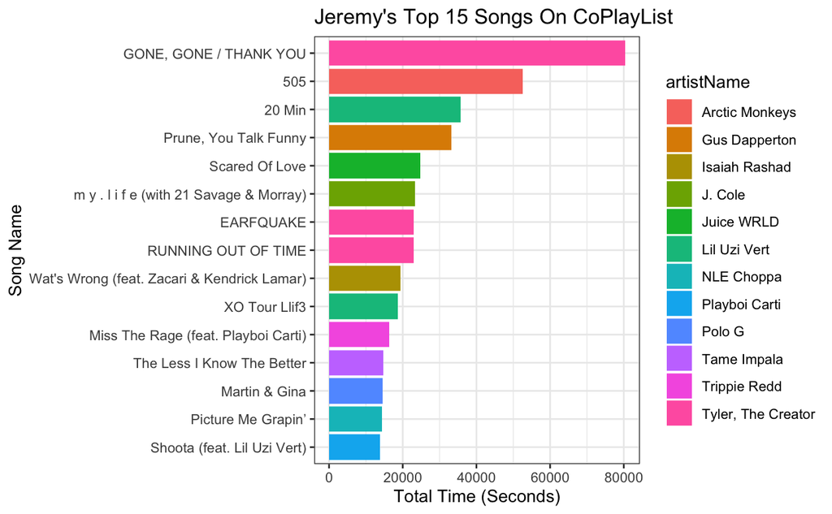

```r
JeremyCoPlay <-
  CoPlaylist %>%
  select(trackName,artistName,sTotal.x,Listener.x) %>%
  arrange(desc(sTotal.x)) %>%
  head(15)
ggplot(JeremyCoPlay) +
  aes(x = reorder(trackName,+sTotal.x), fill = artistName, weight = sTotal.x) +
  geom_bar() +
  scale_fill_hue(direction = 1) +
  labs(title = "Jeremy's Top 15 Songs On CoPlayList") +
  ylab("Total Time (Seconds)") +
  xlab("Song Name") +
  coord_flip() +
  theme_bw()
```

This graphic shows us which songs were each of our favorites from the CoPlaylist.